# Algorithm Class 19 - Practice 12

Review and Something about DFS

June/19/2019

# 1 Queue, Deque, Stack, Vector, and interfaces

## 1.1 Q&A 1

> 關於聲明deque class的問題:

```java
public class Solution {
  public Deque<Integer> stack;
  public Deque<Integer> minStack;

  public solution() {
    stack = new LinkedList<Integer>();
    minStack = new LinkedList<Integer>();
  }

  // ...
}
```

> 這個例題裏, 能否改成`stack = new Deque<Integer>();`這樣呢?

不能, Deque是接口, 不能實例化.

Some possible constructors:

```java
public class Test {
  public static void main(String[] args) {
    Deque<Integer> stack1 = new ArrayDeque<>();
    Deque<Integer> stack2 = new LinkedList<>();
    List<Integer> list1 = new LinkedList<>();
    // ...
  }
}
```

## 1.2 Q&A 2

> 在做題的過程中, 有些題目要使用stack, 我用的是:

```java
Stack<Integer> s = new Stack<Integer>();
```

> 但參考答案中大多是:

```java
Deque<Integer> stack = new LinkedList<>();
```

> 我想請問下是不是這兩種方法都可以? 在面試過程中如果遇到類似Queue by two stacks這種題, 可以直接用Stack這個類嗎?

Stack這個類可以認爲是deprecated了, 在現在的Java中當你需要使用stack這種數據結構的時候應該考慮使用Deque接口.

https://docs.oracle.com/javase/7/docs/api/java/util/Stack.html

例如:

```java
Deque<Integer> stack = new ArrayDeque<Integer>();
```

## 1.3 Q&A 3

> 關於Queue By Two Stacks這道題, laicode java答案中用了兩個linkedlist而非stack來實現, 我先問下這麽做的原因, 以及如果我們在面試中遇到這道題如何選擇用那種數據類型來實現.

Java中用作stack的interface是Deque， 然後它的實現class是LinkedList或者ArrayDeque.

https://docs.oracle.com/javase/7/docs/api/java/util/ArrayDeque.html

You may ask: “But the question asks me to use Stack, Deque is not a stack…”

- If you only use `offerFirst`/`pollFirst` OR only use `offerLast`/`pullLast`, then it IS a STACK.
- If you only use `offerFirst`/`pollLast` OR only use `offerLast`/`pullFirst`, then is IS a QUEUE.

## 1.4 Programming againest interface instead of implementation

We can use interface instead of implementation everywhere except in the “new” statement.

Examples:

| Questions | True of False |
| --- | --- |
| 1. `List<Integer> a = null;` | OK |
| 2. `List<Integer> b = a;` | OK |
| 3. `public void sort(List<Integer>) {...}` | OK |
| 4. `class DataHolder {private List<Comparable> data;}` | OK |
| 5. `List<Integer> list = new List<Integer>();` | Wrong |
| 6. `List<Integer> list = new ArrayList<Integer>();` | OK |
| 7. `List<List<Integer>> lists;` | OK |
| 8. `List<List<Integer>> lists = new List<List<Integer>>();` | Wrong |
| 9. `List<ArrayList<Integer>> lists = new List<ArrayList<Integer>>();` | Wrong |
| 10. `List<List<Integer>> lists = new ArrayList<List<Integer>>();` | OK |
| 11. `List<List<Integer>> lists = new ArrayList<ArrayList<Integer>>();` | Wrong |
| 11b. `List<List<Integer>> lists = new ArrayList<>();` | OK |
| 12. `lists.add(new List<Integer>());` | Wrong |
| 13. `lists.add(new ArrayList<Integer>());` | OK |
| 14. `List<Integer> list = new LinkedList<Integer>();` | OK |

### 1.4.1 Benefits of programming against interface

**1. More flexible:**

- A function whose parameter is interface can take any object types that are implementations of the interface.

```java
package laioffer;
import java.util.*;
class Test {
  public static void main(String[] args) {
    List<Integer> arraylist = new ArrayList<>();
    arraylist.add(1);
    arraylist.add(2);
    arraylist.add(3);
    List<Integer> linkedlist = new LinkedList<>();
    linkedlist.add(1);
    linkedlist.add(2);
    linkedlist.add(3);
    print(arraylist);
    print(linkedlist);
  }

  public static void print(List<Integer> list) {
    for (int i = 0; i < list.size(); i++) {
      System.out.println(list.get(i));
    }
  }
}
```

**2. More extensible:**

- In the future, if there is another implementation of the List interface, there is no need to modify the print function which can be directly used.

# 2 DFS

## 2.1 Problem 1: All Subsets

Given a set of characters represented by a String, return a list containing all subsets of the characters.

Assumptions:

- There are no duplicate characters in the original set.

Examples:

- Set = “abc”, all the subsets are [“”, “a”, “ab”, “abc”, “ac”, “b”, “bc”, “c”]
- Set = “”, all the subsets are [“”]
- Set = null, all the subsets are []

DFS基本方法:

1. How many levels in the recursion tree? What does it store on each level?
   - 3 levels. For each level, it makes the decision on whether to put this element into the final set.
2. How many different states should we try to put on each level?
   - Two. Each state (case) considers either select or not select

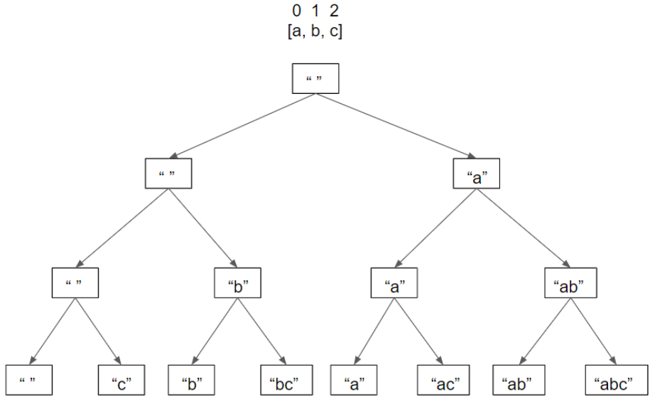

```java
public class SubSets {
  public List<String> subSets(String set) {
    List<String> result = new ArrayList<String>();
    if (set == null) {
      return result;
    }
    char[] arraySet = set.toCharArray();
    StringBuilder sb = new StringBuilder();
    helper(arraySet, sb, 0, result);
    return result;
  }

  private void helper(char[] set, StringBuilder sb, int index, List<String> result) {
    if (index == set.length) {
      result.add(sb.toString());
      return;
    }
    // Case 1: not add the letter
    helper(set, sb, index + 1, result);
    // Case 2: add the letter
    sb.append(set[index]);
    helper(set, sb, index + 1, result);
    sb.deleteCharAt(sb.length() - 1);
  }
}

class Solution{
  public static void main(String[] args) {
    List<String> result = new Subsets().subSets("abc");
    System.out.println(Arrays.toString(result.toArray()));
  }
}
```

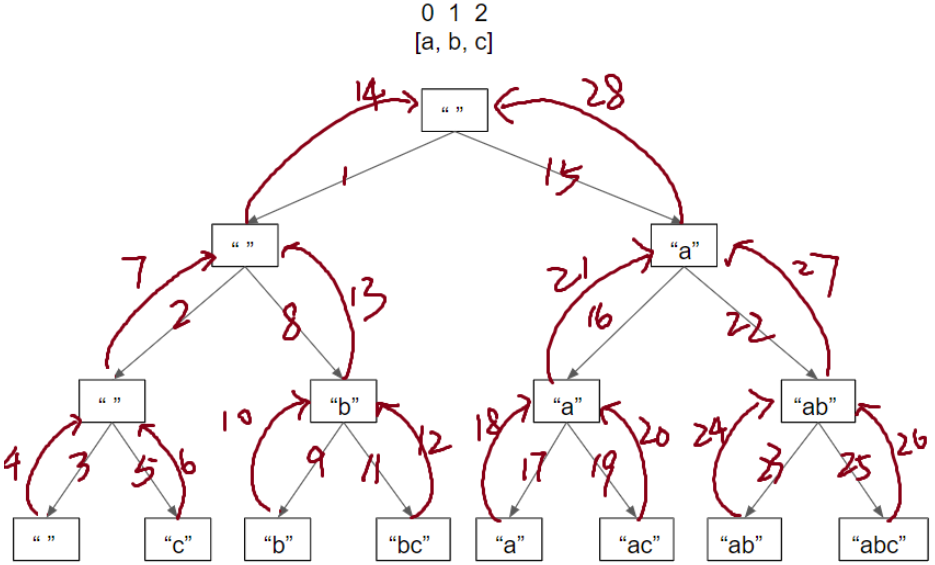

## 2.2 A Better Way of Looking at Recursion

When you call recursive function, don’t let your thoughts follow the recursion into the deepest level!

Instead, only look at the logic of the current level, and **assume** the logic of the next level is reasonable.

Why? Think about Mathematical Induction.

The same idea applies to Recursion.

You only need to convince yourself using the above detailed recursion tree ONCE, don’t do it anytime.

Let’s use mathematical induction idea to look at the code again. (Problem 1)

Question: How to prove the StringBuider `sb` remains unchanged upon entering the helper function and exiting the helper function?

1. When n == length, helper does not change anything proved
2. Assume n = k + 1, helper does not change anything
3. Let’s look at n = k:

```java
// sb size = x
if (index == set.length) {
  result.add(sb.toString());
  return;
}
// sb size = x
helper(set, sb, index + 1, result);
// sb size = x (induction)
sb.append(set[index]);
// sb size = x + 1
helper(set, sb, index + 1, result);
// sb size = x + 1 (induction)
sb.deleteCharAt(sb.length() - 1);
// sb size = x
```

## 2.3 Problem 2: All Valid Permutation of Parentheses

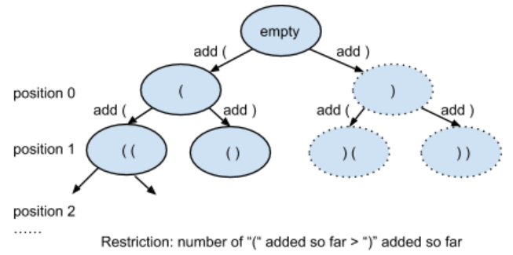

Restriction: Whenever we insert a new “)”, we need to make sure the number of “(” added so far is larger than the number of “)” added so far.

```java
// n stores total number of "pair of ()" need to add. So total levels == 2 * n.
// l stores the number of left parenthesis "(" added so far.
// r stores the number of right parenthesis ")" added so far.
// soluPrefix: solution so far.
void DFS(int n, int l, int r, StringBuilder soluPrefix) {
  // Base case
  if (l == n && r == n) {
    System.out.println(soluPrefix);
    return;
  }

  // Case 1: Add "(" on this level
  if (l < n) {
    soluPrefix.append('(');
    DFS(n, l + 1, r, soluPrefix);
    soluPrefix.deleteCharAt(soluPrefix.length() - 1);
  }

  // Case 2: Add ")" on this level
  if (l > r) {
    soluPrefix.append(')');
    DFS(n, l, r + 1, soluPrefix);
    soluPrefix.deleteCharAt(soluPrefix.length() - 1);
  }
}
```

## 2.4 Problem 3: All Permutations

Given a string with no duplicate characters, return a list with all permutations of the characters.

Examples:

- Set = “abc”, all permutations are [“abc”, “acb”, “bac”, “bca”, “cab”, “cba”]
- Set = “”, all permutations are [“”]
- Set = null, all permutations are []

**Solution 1: “Swap-Swap” way**

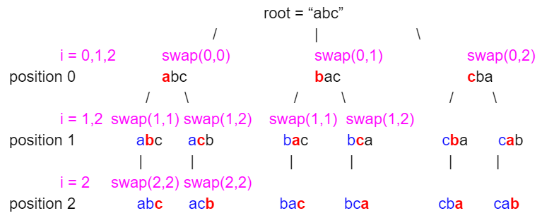

```java
public class PermutationsI {
  // 1. DFS solution with swapping
  public List<String> permutations(String set) {
    List<String> result = new ArrayList<String>();
    if (set == null) {
      return result;
    }
    char[] array = set.toCharArray();
    helper(array, 0, result);
    return result;
  }

  // Choose the character to be at the position of "index", all the already chosen positions are (0, index - 1),  all the candidate characters can be at position "index" are in the subarray of (index, array.length - 1)
  private void helper(char[] array, int index, List<String> result) {
    // Terminate Condition: Only when we have already chosen the characters for all the position, we can have a complete permutation.
    if (index == array.length) {
      result.add(new String(array));
      return;
    }
    // All the possible characters could be placed at index are the characters in the subarray (index, array.length - 1)
    for (int i = index; i < array.length; i++) {
      swap(array, index, i);
      helper(array, index + 1, result);
      // Remember to swap back when back track to previous level.
      sway(array, index, i);
    }
  }

  private void swap(char[] array, int a, int b) {
    char temp = array[a];
    array[a] = array[b];
    array[b] = temp;
  }
}
```

**Solution 2 (Optional)**

```java
public class Solution {
  public List<String> permutations(String set) {
    List<String> result = new ArrayList<>();
    if (set == null) {
      return result;
    }
    StringBuilder sb = new StringBuilder();
    helper(set, sb, result);
    return result;
  }

  private void helper(String set, StringBuilder sb, List<String> result) {
    if (set.isEmpty()) {
      result.add(sb.toString());
      return;
    }
    for (int i = 0; i < set.length(); i++) {
      String newSet = set.substring(0, i) + set.substring(i + 1);
      sb.append(set.charAt(i));
      helper(newSet, sb, result);
      sb.deleteCharAt(sb.length() - 1);
    }
  }
}
```

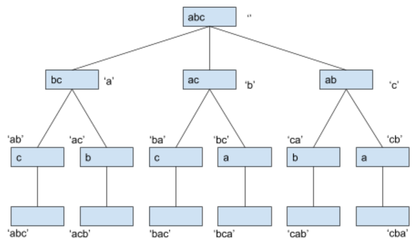

## 2.5 Handling Corner Cases

Sometimes, it needs some care handling corner cases.

1. null != empty string || null != “”
2. null != empty arraylist || `new ArrayList<Integer>() != null`
3. empty arraylist != arraylist with an empty string || [] != [“”]
4. arraylist of arraylist with a null pointer != arraylist of arraylist with an empty arraylist [null] != [[]]

## 2.6 Q&A 4

```java
List<O> result = new ArrayList<O>();
```

> 如果O是ArrayList就要new新的object, add進去, 防止更新下面的ArrayList而改變存進去的reference指向, 但是爲什麽String就不需要呢? 哪些類型的object需要重新new? 哪些不需要呢?

Java中的String是immutable的, 也就是創建後就不可改變的, 所以放進去的時候不用new, 因爲以後不會變.

arraylist相反, 是mutable的, 所以需要clone reference.

**可不可變是決定要不要new的標準, Java中的String, Integer, Double, Long, Boolean等常用數據類型是immutable的, List等容器類型是mutable的.**